# Team Poster Project: Singapore Rainfall Visualisation Redesign

Author

Team Coral

## 1 Project Overview

This project redesigns a published rainfall visualisation about Singapore’s rainfall patterns. The redesign uses station-level daily rainfall observations for Changi from 1980 to 2026.

| Project Component | Redesigned Version |
| --- | --- |
| Original visualisation | “Distribution of daily (left) and monthly (right) rainfall in Singapore; 1983 - 2019” (Chart 5) |
| Redesign topic | Month-by-year flood-stress patterns from heavy and extreme daily rainfall |
| Raw data file | `MSS_Master_Daily_S24_1980_2026.csv` |
| Main variables used | `year`, `month`, `day`, `station`, `daily_rainfall_total_mm` |
| Improved visualisation | Year-month flood-stress matrix using daily heavy-rain and extreme-rain thresholds |

### 1.1 Original Visualisation and Critique

The original Chart 5 in *Visualising Singapore’s Changing Weather Patterns: 1983–2019* by Chua Chin Hon was designed to show the distribution of daily (left) and monthly (right) rainfall. It plotted every daily observation and monthly total chronologically as a scatter plot over time. The $y$-axes were inverted, and points were mapped to size and color based on rainfall intensity.

Our critique identifies five main weaknesses:

1. **Overplotting and Noise:** Daily rainfall is highly skewed (most days are dry). Scatterplotting 13,000+ points results in a dense block of overlapping points at $0\text{ mm}$ that obscures the actual distribution.
2. **Inverted Vertical Axis:** Larger rainfall amounts are plotted downwards. This is counterintuitive for readers and makes it difficult to read and compare quantities.
3. **Incomparable Shared Y-Axis:** The subplots share a y-axis. Daily rainfall ($0\text{--}150\text{ mm}$) has a completely different range from monthly rainfall ($0\text{--}700\text{ mm}$), causing the daily plot to be heavily compressed at the top.
4. **Redundant Channel Mapping:** Mapping rainfall to position, color (hue), and point size simultaneously creates visual clutter without conveying additional variables.
5. **No Planning Threshold Context:** Plotting raw points chronologically does not show how often rainfall crosses practical heavy-rain or extreme-rain thresholds in each month and year.

### 1.2 Design Brief

Our plan for this redesign is for urban planners, environmental agencies, and policymakers in Singapore. The goal is to show when heavy-rain and extreme-rain days cluster across months and years, so readers can compare seasonal flood-stress patterns without scanning thousands of daily points.

*Main revisions:*

- **Year-Month Matrix Layout** to preserve both the long-term record and month-by-month seasonality in one view.
- **Heavy-Rain Day Classes** to encode the monthly count of days with at least $50\text{ mm}$ of rainfall.
- **Extreme-Rain Markers** to flag days with at least $100\text{ mm}$ of rainfall without hiding the heavy-rain count.
- **Complete-Year Filtering** to use 1983–2025 and exclude the incomplete 2026 record from year-to-year comparison.

## 2 Import the Rainfall Data

The raw dataset is stored as a CSV file. The code below searches for the file in the project root first and then in `data/raw/` to ensure the report renders reliably.

```
# A tibble: 16,953 × 13
   Station  Year Month   Day `Daily Rainfall Total (mm)` Highest 30 Min Rainfa…¹
   <chr>   <dbl> <dbl> <dbl>                       <dbl>                   <dbl>
 1 Changi   1980     1     1                         0                        NA
 2 Changi   1980     1     2                         0                        NA
 3 Changi   1980     1     3                         0                        NA
 4 Changi   1980     1     4                         0                        NA
 5 Changi   1980     1     5                         8                        NA
 6 Changi   1980     1     6                         9.1                      NA
 7 Changi   1980     1     7                         7.9                      NA
 8 Changi   1980     1     8                         0                        NA
 9 Changi   1980     1     9                         0                        NA
10 Changi   1980     1    10                         0                        NA
# ℹ 16,943 more rows
# ℹ abbreviated name: ¹`Highest 30 Min Rainfall (mm)`
# ℹ 7 more variables: `Highest 60 Min Rainfall (mm)` <dbl>,
#   `Highest 120 Min Rainfall (mm)` <dbl>, `Mean Temperature (°C)` <dbl>,
#   `Maximum Temperature (°C)` <dbl>, `Minimum Temperature (°C)` <dbl>,
#   `Mean Wind Speed (km/h)` <dbl>, `Max Wind Speed (km/h)` <dbl>
```

## 3 Clean the Rainfall Data

The raw file stores date information across separate year, month, and day columns. We clean the column names, convert the date fields to integers, create a proper `date` column, parse rainfall as a numeric variable, and trim whitespace from the station name.

```
# A tibble: 6 × 15
  station  year month   day daily_rainfall_total_mm highest_30_min_rainfall_mm
  <chr>   <int> <int> <int>                   <dbl>                      <dbl>
1 Changi   1980     1     1                     0                           NA
2 Changi   1980     1     2                     0                           NA
3 Changi   1980     1     3                     0                           NA
4 Changi   1980     1     4                     0                           NA
5 Changi   1980     1     5                     8                           NA
6 Changi   1980     1     6                     9.1                         NA
# ℹ 9 more variables: highest_60_min_rainfall_mm <dbl>,
#   highest_120_min_rainfall_mm <dbl>, mean_temperature_c <dbl>,
#   maximum_temperature_c <dbl>, minimum_temperature_c <dbl>,
#   mean_wind_speed_km_h <dbl>, max_wind_speed_km_h <dbl>, date <date>,
#   month_name <fct>
```

```
# A tibble: 6 × 15
  station         year month   day daily_rainfall_total…¹ highest_30_min_rainf…²
  <chr>          <int> <int> <int>                  <dbl>                  <dbl>
1 Changi Met. S…  2026     5    26                    1                      1
2 Changi Met. S…  2026     5    27                    0                      0
3 Changi Met. S…  2026     5    28                    0                      0
4 Changi Met. S…  2026     5    29                    1.6                    1.4
5 Changi Met. S…  2026     5    30                    5                      2.2
6 Changi Met. S…  2026     5    31                    0                      0
# ℹ abbreviated names: ¹daily_rainfall_total_mm, ²highest_30_min_rainfall_mm
# ℹ 9 more variables: highest_60_min_rainfall_mm <dbl>,
#   highest_120_min_rainfall_mm <dbl>, mean_temperature_c <dbl>,
#   maximum_temperature_c <dbl>, minimum_temperature_c <dbl>,
#   mean_wind_speed_km_h <dbl>, max_wind_speed_km_h <dbl>, date <date>,
#   month_name <fct>
```

### 3.1 Verify the Cleaned Data

These checks confirm the observed date range, duplicate dates, missing dates, missing rainfall values, and impossible negative rainfall values.

```
# A tibble: 8 × 2
  check                               value
  <chr>                               <chr>
1 rows                                16953
2 first_date                          1980-01-01
3 last_date                           2026-05-31
4 invalid_dates                       0
5 duplicate_dates                     0
6 missing_dates_inside_observed_range 0
7 missing_daily_rainfall_values       0
8 negative_daily_rainfall_values      0
```

```
# A tibble: 2 × 4
  station             first_date last_date  n_days
  <chr>               <date>     <date>      <int>
1 Changi              1980-01-01 2026-01-31  16833
2 Changi Met. Station 2026-02-01 2026-05-31    120
```

```
# A tibble: 1 × 3
  date       previous_station station
  <date>     <chr>            <chr>
1 2026-02-01 Changi           Changi Met. Station
```

The station history check confirms that these are station-level observations for Changi.

### 3.2 Export the Cleaned Daily Data

We write the cleaned daily dataset to `data/processed/` to ensure project reproducibility.

## 4 Derive Monthly Reference Data

We aggregate the daily rainfall observations into monthly totals as supporting reference data for the cleaning workflow. To handle incomplete data, we generate a complete year-month grid and classify each month as complete, partial, or unavailable. The final redesign in Section 5 uses daily rainfall directly because flood-stress thresholds are day-level events.

```
# A tibble: 6 × 6
  month_name median_val   q10   q25   q75   q90
  <fct>           <dbl> <dbl> <dbl> <dbl> <dbl>
1 Jan              198.  61.0 103.   307.  488.
2 Feb               78   12.2  31.8  166.  216.
3 Mar              137.  51.2  77.3  247.  301.
4 Apr              160.  72.9 110.   214.  241.
5 May              157.  69.7 105.   209.  256.
6 Jun              125.  56.2  89.9  184.  239.
```

## 5 Redesigned Visualisations

This is the primary redesign chart for urban planners, environmental agencies, and policymakers in Singapore. Each column is one year and each row is one calendar month. Every cell in the grid covers one month in one year across the full 1983-2025 record.

The tile color encodes the number of heavy-rain days (daily rainfall ≥ 50 mm) in each month-year using a four-level discrete scale: 0 days (near-white), 1 day (light blue), 2 days (mid blue), 3 or more days (dark blue). Red circle markers appear over cells that contained at least one extreme-rain day (daily rainfall ≥ 100 mm); the size of the circle scales with the count of extreme days in that cell.

This keeps two planning signals visible at once: the seasonal clustering of heavy-rain months and isolated high-severity events that do not follow the seasonal pattern.

```
# A tibble: 1 × 6
  first_date last_date  n_years n_days missing_month_values
  <date>     <date>       <int>  <int>                <int>
1 1983-01-01 2025-12-31      43  15706                    0
# ℹ 1 more variable: missing_daily_rainfall_values <int>
```

```
# A tibble: 1 × 6
  n_years n_months n_cells max_heavy_days_in_month_year max_extreme_days_in_mo…¹
    <int>    <int>   <int>                        <int>                    <int>
1      43       12     516                            5                        3
# ℹ abbreviated name: ¹max_extreme_days_in_month_year
# ℹ 1 more variable: missing_heavy_day_classes <int>
```

```
# A tibble: 15 × 6
    year month_name heavy_days_50_99 extreme_days_100_plus heavy_days_50_plus
   <int> <fct>                 <int>                 <int>              <int>
 1  2006 Dec                       3                     2                  5
 2  1989 Nov                       4                     1                  5
 3  1987 Jan                       4                     1                  5
 4  2004 Jan                       2                     2                  4
 5  1992 Nov                       2                     2                  4
 6  2001 Dec                       3                     1                  4
 7  2025 Jan                       3                     1                  4
 8  1984 Feb                       3                     1                  4
 9  2024 Jan                       4                     0                  4
10  2019 Dec                       4                     0                  4
11  2021 Jan                       0                     3                  3
12  2007 Dec                       1                     2                  3
13  2011 Jan                       2                     1                  3
14  2025 Mar                       2                     1                  3
15  1988 Sep                       2                     1                  3
# ℹ 1 more variable: max_daily_mm <dbl>
```

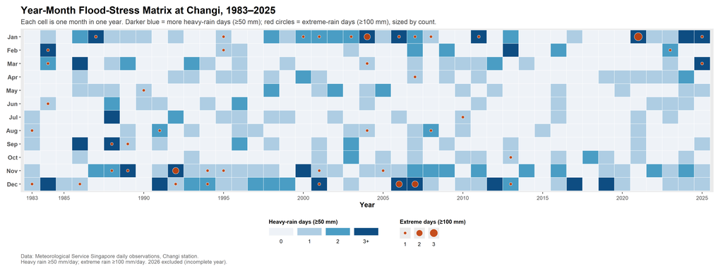

## Quick Reading

**Selected main redesign: Year-Month Flood-Stress Matrix.**

This chart was chosen because it preserves both planning dimensions at once: the full 43-year record and the month-by-month separation. Stakeholders can scan the poster and answer two questions at the same time — which months are seasonally risky, and what is the pattern for years that produced unusual events?

## 7 Poster Notes

Key points to transfer to the poster:

1. **Station-Level Specificity:** The data are station-level rainfall observations for Changi, not a national average for Singapore.
2. **Date Range Coverage:** The observed date range is 1980-01-01 to 2026-05-31.
3. **Complete-Year Comparison:** The matrix uses 1983-2025 only; 2026 is excluded because the source record stops at 2026-05-31.
4. **Heavy-Rain Frequency:** Darker cells show months with repeated days at or above $50\text{ mm}$, making seasonal flood-stress clusters easier to scan.
5. **Extreme-Rain Severity:** Red circles flag days at or above $100\text{ mm}$, so isolated high-severity events remain visible even when monthly heavy-rain frequency is low.

## 8 References

1. Chua Chin Hon (2019). “Visualising Singapore’s Changing Weather Patterns: 1983-2019”. *Towards Data Science*. [Medium Article](https://medium.com/data-science/visualising-singapores-changing-weather-patterns-1983-2019-a78605fadbdf).
2. Historical Daily Weather Records. Meteorological Service Singapore (MSS). [MSS Historical Data](http://www.weather.gov.sg/climate-historical-daily/).